# Baby Names Analysis and Report

Abstract

This report consists of a concise analysis and investigation to shed light on the factors affecting baby names. This is specficially done for a New York based kids’ toy design agency.

# Question One

## 1.1 Pesristence in Popular Names

- The figure below shows the persistence of the top 25 popular names and that of the next 3 years
- F is female, while M is Male
- There is a significant peak during the late 1990s/2000s
- indication a strong persistence of popular names through this period for both males and females
- There is a sharp decline after the peak in 2000,
- suggesting a return to more frequent changes in name popularity.
- Since the 2000’s there is a significant decrease in persistent name popularity for both males and females.
- The recent data shows name popularity does not persist as it once did.

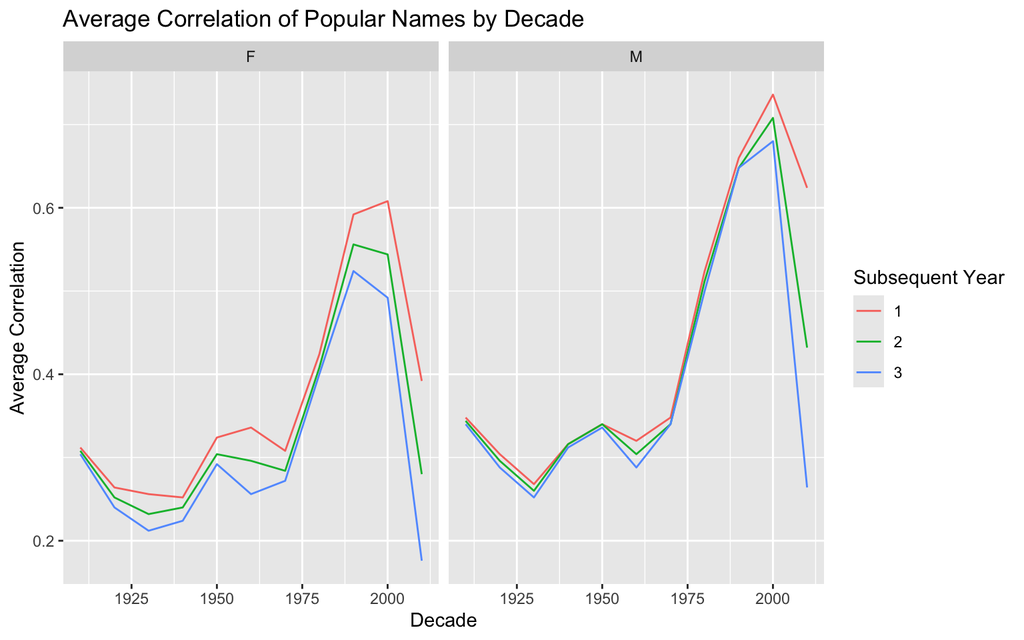

# 1.2 Similarities between Names and Billboard Hot 100 for New York.

- The figure below shows the matching of the popularity of names (New York.) and artists who peaked number one on the Billboard Hot 100 since 2000.
- We have suggested that baby names in a given period would be based on popular artist names in previous periods.
- New York is used specifically as this is where the agency is based
- The x-axis represents the most popular baby names that matched artist names from 2010 to 2014.
- Aiden, David, Liam and Lucas were popular in some years but not at all in other years. This can be a result of a popular artist having no hits or in recent times became popular
- Names such as Emma, Ethan, Jacob, Isabella, Michael and Sophia were constantly popular over these years.

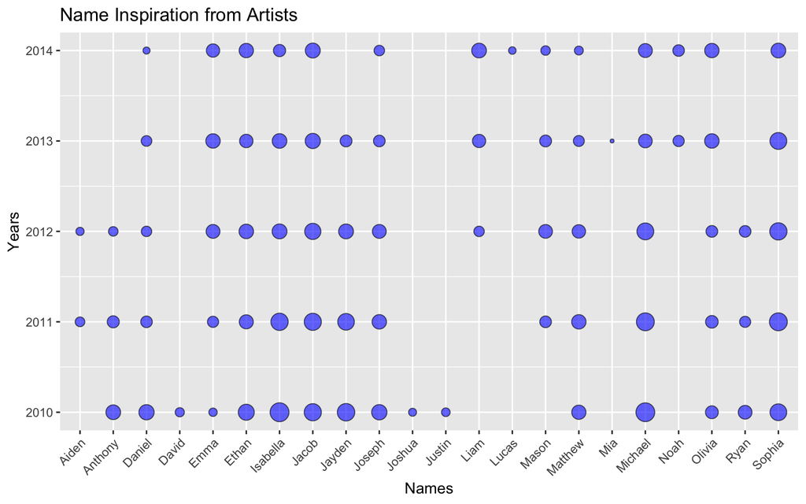

- This figure now subsets the artist on the Billboard Hot 100 since 2014 and not 2000
- We find that some names are no longer popular
- Anthony and Justin are names that seem do not match any artists names

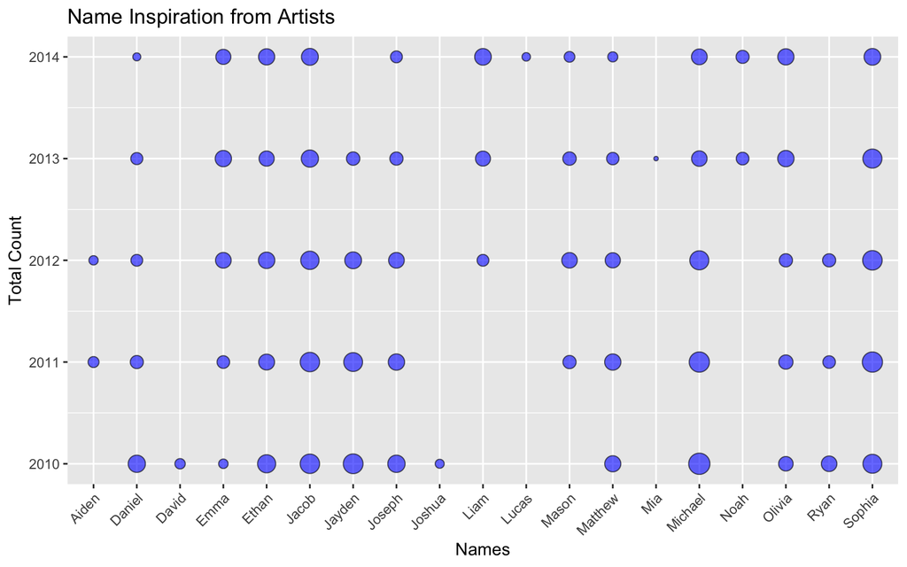

## 2. Conclusion

This report concludes by suggesting that there is less persistence since the 2000’s in popular baby names for both males and females. There is more frequent changes in name popularity. There is however many matches between popular baby names and successful music artists. Our plots suggest a whole list of toy names that could be successful especially in New York.